# Coursera Capstone Milestone Project

Edward Lee

March 18, 2016

## Setting the Libraries and Path

This is from reading the forum and performing EDA on the dataset

## Now let’s start by reading in the file for the project

```r
twits <- readLines("final/en_US/en_US.twitter.txt", encoding="UTF-8")
blogs <- readLines("final/en_US/en_US.blogs.txt", encoding="UTF-8")

# The news file did not have an end of line character - found this on the forum
newstemp <-file("final/en_US/en_US.news.txt", open="rb")
news <- readLines(newstemp, encoding="UTF-8")
close(newstemp)
rm(newstemp)
```

## Basic EDA and 5% sampling

File Size, Number of Sentences, word Counts

```r
# what are the sizes for the files - I have it in Windows so I can check, but will do it the hard way as well
file.info("final/en_US/en_US.blogs.txt")$size
```

```
## [1] 210160014
```

```r
file.info("final/en_US/en_US.twitter.txt")$size
```

```
## [1] 167105338
```

```r
file.info("final/en_US/en_US.news.txt")$size
```

```
## [1] 205811889
```

```r
# About 250 megabits each

# let's count each line and count how many records are in each line - Using stringi!!!
stri_stats_general(blogs)
```

```
##       Lines LinesNEmpty       Chars CharsNWhite
##      899288      899288   206824382   170389539
```

```r
stri_stats_general(twits)
```

```
##       Lines LinesNEmpty       Chars CharsNWhite
##     2360148     2360148   162096031   134082634
```

```r
stri_stats_general(news)
```

```
##       Lines LinesNEmpty       Chars CharsNWhite
##     1010242     1010242   203223154   169860866
```

```r
# We can start with a 5% sample, that should be enough - will do rough estimate from output above
sblog <- sample(blogs,size=45000)
stwits <- sample(twits,size=110000)
snews <- sample(news,size=51000)

# since the blog and news are in paragraphs, I will like to parse it out to sentences.
# for the twits, it was screwing up the tm lowercase function adding a step
sblogsSentences <- strsplit( sblog, "[.]|[!]|[?]")
snewsSentences <- strsplit( snews, "[.]|[!]|[?]")
stwits <- sapply(stwits,function(row) iconv(row, "latin1", "ASCII", sub=""))
```

### Word Frequency Check and WordCloud (because WordCloud looks cool)

Need to dump the data into a Corpus I saw some of the other students had stopword and stem word removed. Not sure if that is a good idea. So I will NOT use them

```r
# Blogs first
bcorpus <- VCorpus(VectorSource(sblogsSentences))

bcorpus1 <- tm_map(bcorpus, removePunctuation)
bcorpus2 <- tm_map(bcorpus1, removeNumbers)
bcorpus3 <- tm_map(bcorpus2, content_transformer(tolower))

# News
ncorpus <- VCorpus(VectorSource(snewsSentences))

ncorpus1 <- tm_map(ncorpus, removePunctuation)
ncorpus2 <- tm_map(ncorpus1, removeNumbers)
ncorpus3 <- tm_map(ncorpus2, content_transformer(tolower))

# Twits - yes,this should have been a function.... but it is on my R script!
tcorpus <- VCorpus(VectorSource(stwits))

tcorpus1 <- tm_map(tcorpus, removePunctuation)
tcorpus2 <- tm_map(tcorpus1, removeNumbers)
tcorpus3 <- tm_map(tcorpus2, content_transformer(tolower))
```

## Show The Word Cloud

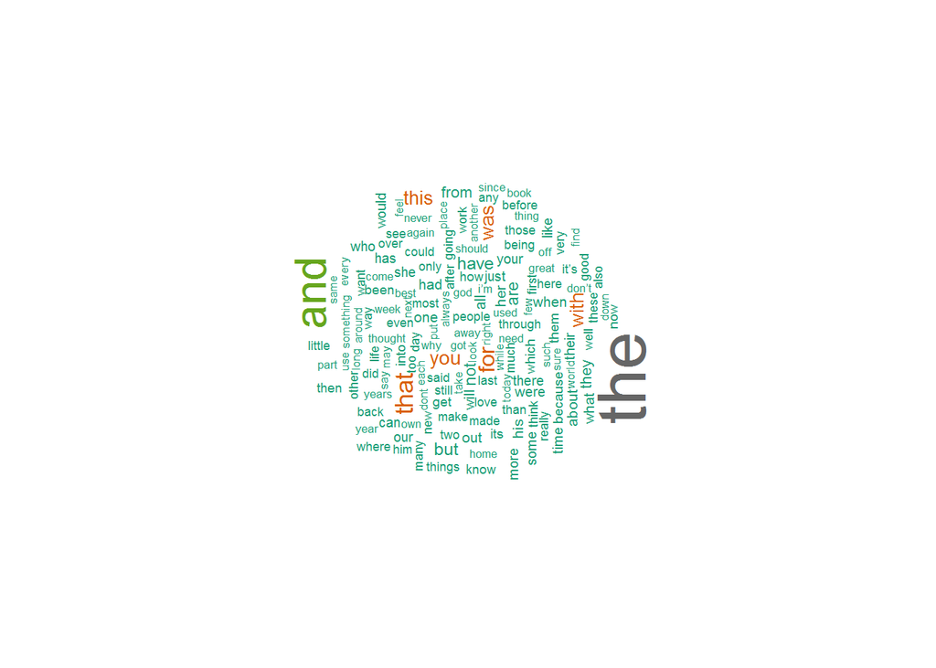

```r
wordcloud(bcorpus3, scale=c(3,0.5),
          min.freq=5, max.words=150, random.order=TRUE,
          rot.per=0.5, use.r.layout=FALSE,
          colors=brewer.pal(8, "Dark2"))
```

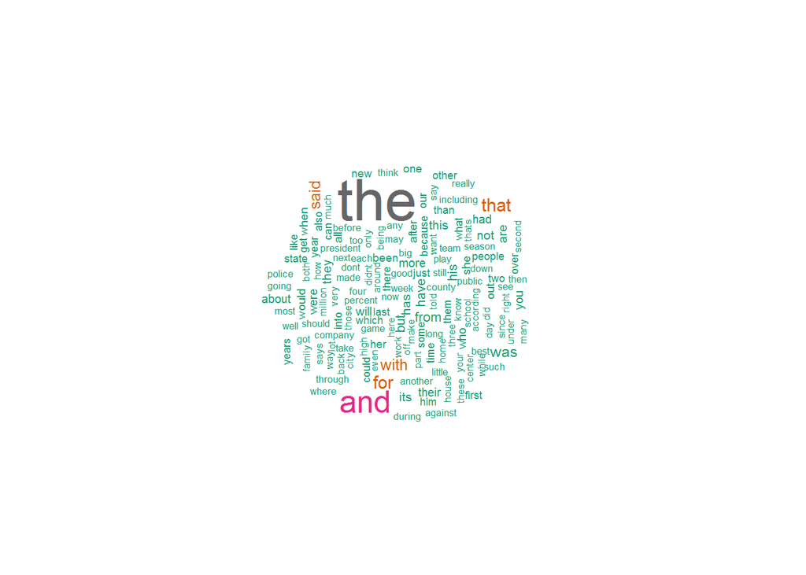

```r
wordcloud(ncorpus3, scale=c(3,0.5),
          min.freq=5, max.words=150, random.order=TRUE,
          rot.per=0.5, use.r.layout=FALSE,
          colors=brewer.pal(8, "Dark2"))
```

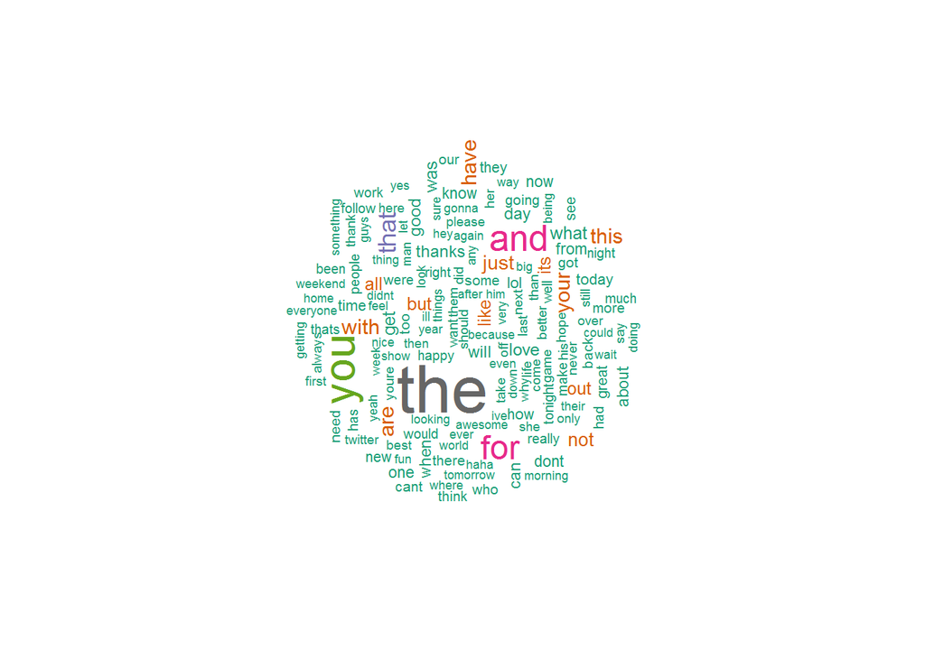

```r
wordcloud(tcorpus3, scale=c(3,0.5),
          min.freq=5, max.words=150, random.order=TRUE,
          rot.per=0.5, use.r.layout=FALSE,
          colors=brewer.pal(8, "Dark2"))
```

## We see the usual suspects in the most common word for all 3 types of text block

### So I will do the following for further analysis

1. No profanities filter - I like it this way… and it seems people don’t curse that much
2. No stemming or stopwords, we are trying to predict the next word, all is fair
3. Combine the 3 types of blog, news and twits into one file for model building.
4. That’s it for now